# Titanic_EDA

```python
import pandas as pd
import numpy as np
import matplotlib.pyplot as plt
import seaborn as sns

sns.set_style("whitegrid")
```

```python
df = pd.read_csv("train.csv")
df.head()
```

|  | PassengerId | Survived | Pclass | Name | Sex | Age | SibSp | Parch | Ticket | Fare | Cabin | Embarked |
| --- | --- | --- | --- | --- | --- | --- | --- | --- | --- | --- | --- | --- |
| 0 | 1 | 0 | 3 | Braund, Mr. Owen Harris | male | 22.0 | 1 | 0 | A/5 21171 | 7.2500 | NaN | S |
| 1 | 2 | 1 | 1 | Cumings, Mrs. John Bradley (Florence Briggs Th... | female | 38.0 | 1 | 0 | PC 17599 | 71.2833 | C85 | C |
| 2 | 3 | 1 | 3 | Heikkinen, Miss. Laina | female | 26.0 | 0 | 0 | STON/O2. 3101282 | 7.9250 | NaN | S |
| 3 | 4 | 1 | 1 | Futrelle, Mrs. Jacques Heath (Lily May Peel) | female | 35.0 | 1 | 0 | 113803 | 53.1000 | C123 | S |
| 4 | 5 | 0 | 3 | Allen, Mr. William Henry | male | 35.0 | 0 | 0 | 373450 | 8.0500 | NaN | S |

```python
df.info()
```

```
<class 'pandas.core.frame.DataFrame'>
RangeIndex: 891 entries, 0 to 890
Data columns (total 12 columns):
 #   Column       Non-Null Count  Dtype
---  ------       --------------  -----
 0   PassengerId  891 non-null    int64
 1   Survived     891 non-null    int64
 2   Pclass       891 non-null    int64
 3   Name         891 non-null    object
 4   Sex          891 non-null    object
 5   Age          714 non-null    float64
 6   SibSp        891 non-null    int64
 7   Parch        891 non-null    int64
 8   Ticket       891 non-null    object
 9   Fare         891 non-null    float64
 10  Cabin        204 non-null    object
 11  Embarked     889 non-null    object
dtypes: float64(2), int64(5), object(5)
memory usage: 83.7+ KB
```

```python
df.describe()
```

|  | PassengerId | Survived | Pclass | Age | SibSp | Parch | Fare |
| --- | --- | --- | --- | --- | --- | --- | --- |
| count | 891.000000 | 891.000000 | 891.000000 | 714.000000 | 891.000000 | 891.000000 | 891.000000 |
| mean | 446.000000 | 0.383838 | 2.308642 | 29.699118 | 0.523008 | 0.381594 | 32.204208 |
| std | 257.353842 | 0.486592 | 0.836071 | 14.526497 | 1.102743 | 0.806057 | 49.693429 |
| min | 1.000000 | 0.000000 | 1.000000 | 0.420000 | 0.000000 | 0.000000 | 0.000000 |
| 25% | 223.500000 | 0.000000 | 2.000000 | 20.125000 | 0.000000 | 0.000000 | 7.910400 |
| 50% | 446.000000 | 0.000000 | 3.000000 | 28.000000 | 0.000000 | 0.000000 | 14.454200 |
| 75% | 668.500000 | 1.000000 | 3.000000 | 38.000000 | 1.000000 | 0.000000 | 31.000000 |
| max | 891.000000 | 1.000000 | 3.000000 | 80.000000 | 8.000000 | 6.000000 | 512.329200 |

```python
df.isnull().sum()
```

```
PassengerId      0
Survived         0
Pclass           0
Name             0
Sex              0
Age            177
SibSp            0
Parch            0
Ticket           0
Fare             0
Cabin          687
Embarked         2
dtype: int64
```

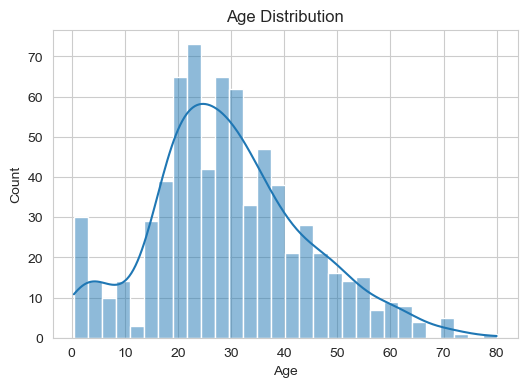

```python
import matplotlib.pyplot as plt
import seaborn as sns

plt.figure(figsize=(6,4))
sns.histplot(df['Age'], bins=30, kde=True)
plt.title("Age Distribution")
plt.show()
```

### Observation:

- The age distribution of passengers is slightly right-skewed.
- Most passengers fall in the age range of 20–40 years, indicating a predominantly young adult population onboard.
- Very few passengers were elderly (above 60 years), and a smaller proportion were children.
- This suggests that the Titanic mainly carried young and middle-aged adults, which may influence survival-related patterns.

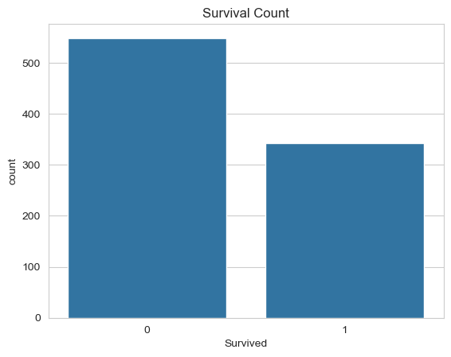

```python
sns.countplot(x='Survived', data=df)
plt.title("Survival Count")
plt.show()
```

### Survival Count Observation:

- The number of passengers who did not survive is higher than those who survived.
- This indicates that the overall survival rate on the Titanic was low.
- The dataset is imbalanced with respect to the target variable (Survived), which is important to consider during analysis and modeling.

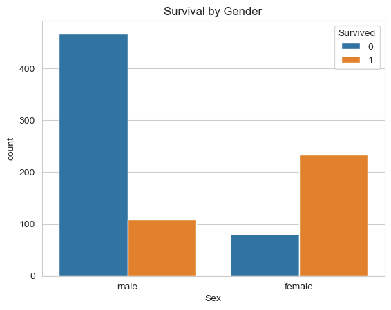

```python
sns.countplot(x='Sex', hue='Survived', data=df)
plt.title("Survival by Gender")
plt.show()
```

### Survival by Gender Observation:

- Female passengers had a significantly higher survival rate compared to male passengers.
- A large proportion of male passengers did not survive, whereas most female passengers survived.
- This indicates that gender played a crucial role in survival, likely due to evacuation priorities during the disaster.

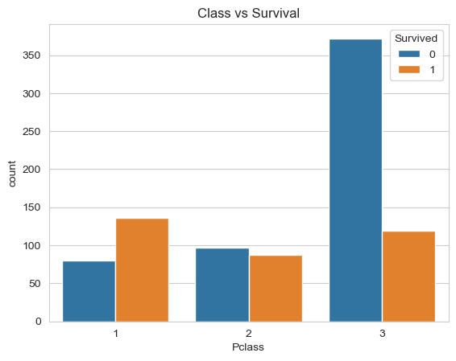

```python
sns.countplot(x='Pclass', hue='Survived', data=df)
plt.title("Class vs Survival")
plt.show()
```

### Survival by Passenger Class Observation:

- Passengers in first class (Pclass = 1) had the highest survival rate.
- Survival rate decreases as passenger class moves from first to third class.
- A large number of third-class passengers did not survive compared to first- and second-class passengers.
- This indicates that socio-economic status and access to resources played a significant role in survival.

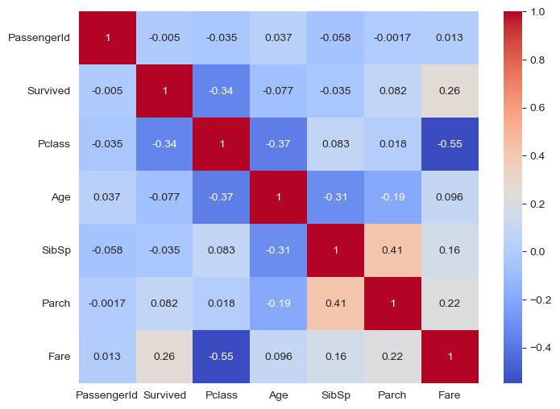

```python
plt.figure(figsize=(8,6))
sns.heatmap(df.corr(numeric_only=True), annot=True, cmap="coolwarm")
plt.show()
```

### Correlation Heatmap Observation:

- Survival shows a moderate positive correlation with Fare, indicating that passengers who paid higher fares were more likely to survive.
- Survival has a negative correlation with Pclass, suggesting that lower-class passengers had lower survival chances.
- Pclass and Fare show a strong negative correlation, meaning higher-class passengers generally paid higher fares.
- Other features such as Age, SibSp, and Parch show weak correlations with survival.

### Insight:

- Fare and passenger class are important predictors of survival.
- No strong multicollinearity is observed among most features, except between Pclass and Fare.

## 🔍 Summary of Findings

- The majority of passengers were young adults aged between 20–40 years.
- Overall survival rate was low, with more passengers not surviving.
- Female passengers and first-class passengers had significantly higher survival rates.
- Higher fares were associated with better survival outcomes.
- Passenger class and fare emerged as key factors influencing survival.